# Tugas Pertemuan 4

Naufal Azizan Rafiansyah

2025-09-22

# White Noise

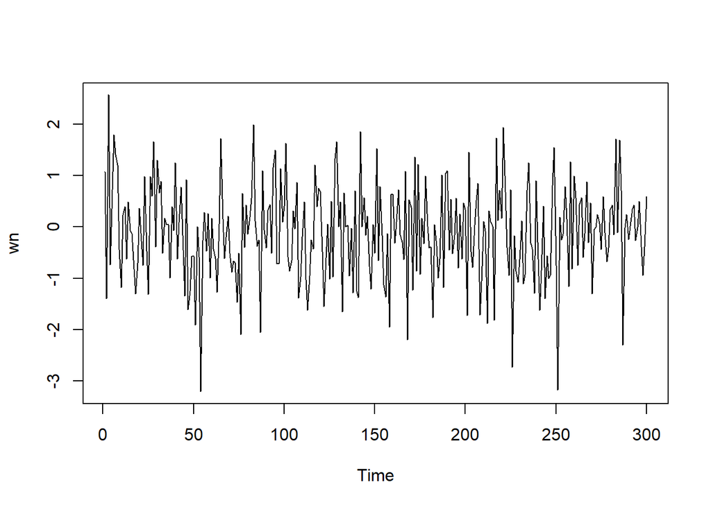

```r
set.seed(1009)
wn <- rnorm(300)
ts.plot(wn)
```

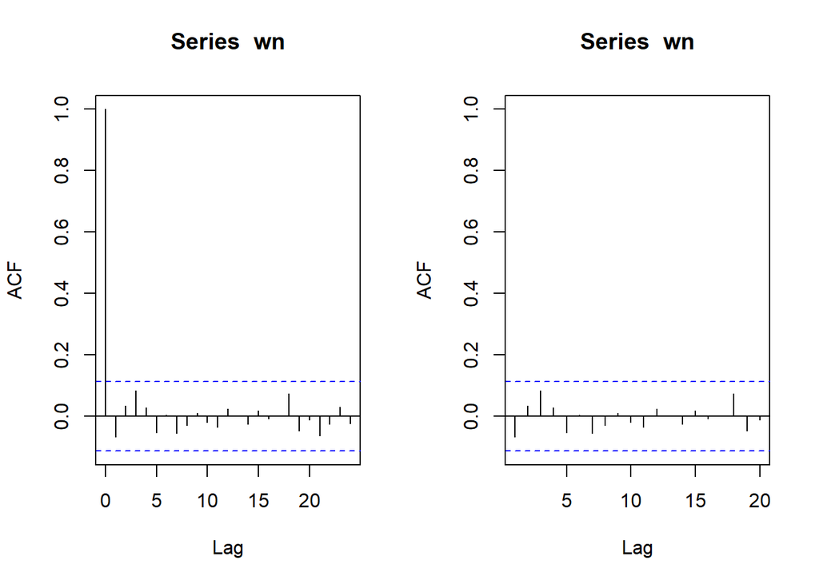

```r
par(mfrow = c(1, 2))
acf(wn)
acf(wn, xlim = c(1, 20))
```

# Proses MA(2)

Akan dibangkitkan secara manual sebanyak 300 data dengan model MA(2) yang memiliki nilai $\theta_1 = 0.4$ dan $\theta_2 = 0.6$.

$$y_t = e_t-0.4e_{t-1}-0.6e_{t-2}$$

```r
set.seed(1009)
ma <- c(1:300)
ma[1] <- wn[1]
ma[2] <- wn[2] - 0.4 * wn [1]
```

```r
for(i in 3:300){
   ma[i] <- wn[i] - 0.4 * wn[i - 1] - 0.6 * wn[i - 2]
}
ma
```

```
##   [1]  1.067940246 -1.821654901  2.486034743 -0.927862261 -0.521669461
##   [6]  1.948461351  0.255901339 -0.434447536 -1.766439330 -1.727770198
##  [11]  0.968296434  1.004394780 -0.918283755  0.498915581  0.112720202
##  [16] -0.392883899 -0.730960704 -0.892792750  0.311492382  1.420485687
##  [21]  0.155107571 -0.914831973  1.351547637 -0.412936886 -1.709351263
##  [26]  1.788184011  0.990984267  0.831052821 -1.408879648  0.453766614
##  [31]  0.378118211 -0.160936219 -1.267251184 -0.160346499  0.301296192
##  [36] -0.078055877 -1.045575135  0.762239286  0.369918041  1.036275213
##  [41] -1.077413938 -0.413423804  1.112805361 -0.524466480 -1.737545219
##  [46]  1.550777923 -1.172062652 -1.154283009  0.897794243  0.405871050
##  [51] -1.341777693  1.110127382  0.565385513 -2.975554405  1.366551713
##  [56]  2.312114693 -0.422459341  0.272322249 -0.814098787  0.413405708
##  [61]  0.103622961 -0.549756228 -0.769117100  0.936216616  2.458033248
##  [66] -0.568212391 -1.708530831 -0.052617451  0.660786793 -0.467054790
##  [71] -0.805911623 -0.009858114  0.098025783 -0.782110661  0.493504372
```

[output cut: 45 more lines]

```r
set.seed(1009)
ma2 <- arima.sim(list(order=c(0,0,2), ma= c(0.4, 0.6)), n=300)
ma2
```

```
## Time Series:
## Start = 1
## End = 300
## Frequency = 1
##   [1]  2.65198000 -0.54603093  1.97158211  1.64409050  2.56286967  2.84859197
##   [7]  0.89048105 -0.62966685 -0.50025335 -0.22285022 -0.32484008  0.47059279
##  [13] -0.24535075  0.13576890 -0.91338503 -1.70480004 -1.71415218 -0.69913391
##  [19] -0.39794760 -0.57915691  0.60824807 -0.52541194 -0.90881337  0.17790887
##  [25]  0.20652264  2.48971131  0.63793015  2.13784529  0.95219327  1.92615552
##  [31]  0.23702342  0.48669398 -0.18630147  0.16375050 -0.94230045  0.01850582
##  [37] -0.51050927  1.44848579 -0.16786428  0.57932151  0.43199752  0.19299329
##  [43] -0.94325277  0.27957482 -2.04840035 -1.34425656 -2.03389939 -1.54769475
##  [49] -2.48017026 -1.10374602 -1.72523071 -3.43566367 -1.89384264 -1.74553252
##  [55] -0.51220103  0.23840741 -1.17060315 -0.07403727 -0.95145083 -0.68526631
##  [61] -1.77182283 -0.82117288  0.97948678  0.87582186  0.47702497 -0.36065411
```

[output cut: 39 more lines]

## Karakteristik MA(2)

### Plot Time Series

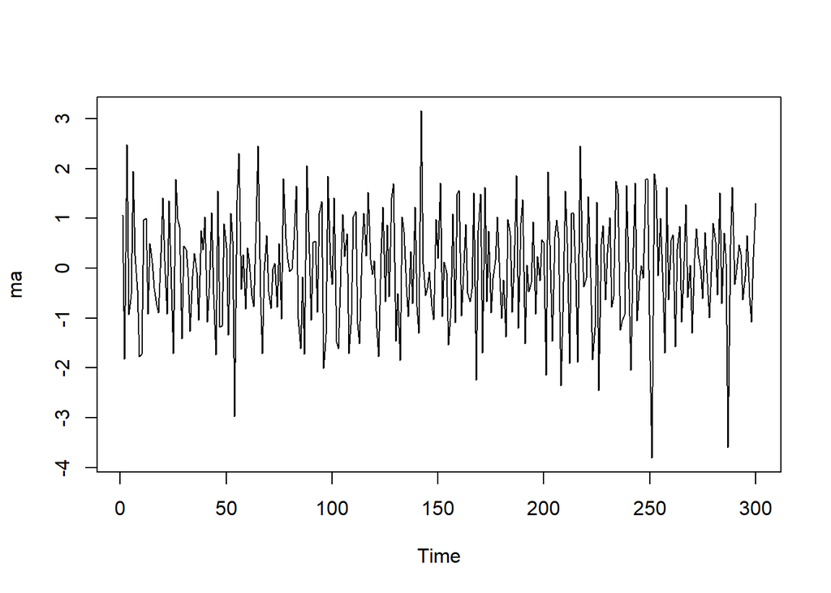

```r
ts.plot(ma)
```

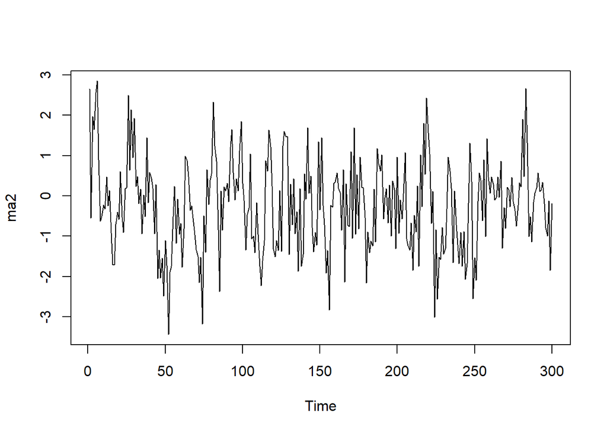

```r
ts.plot(ma2)
```

Berdasarkan plot time series, terlihat bahwa data MA(2) yang dibangkitkan cenderung stasioner dalam rataan.

### Plot ACF

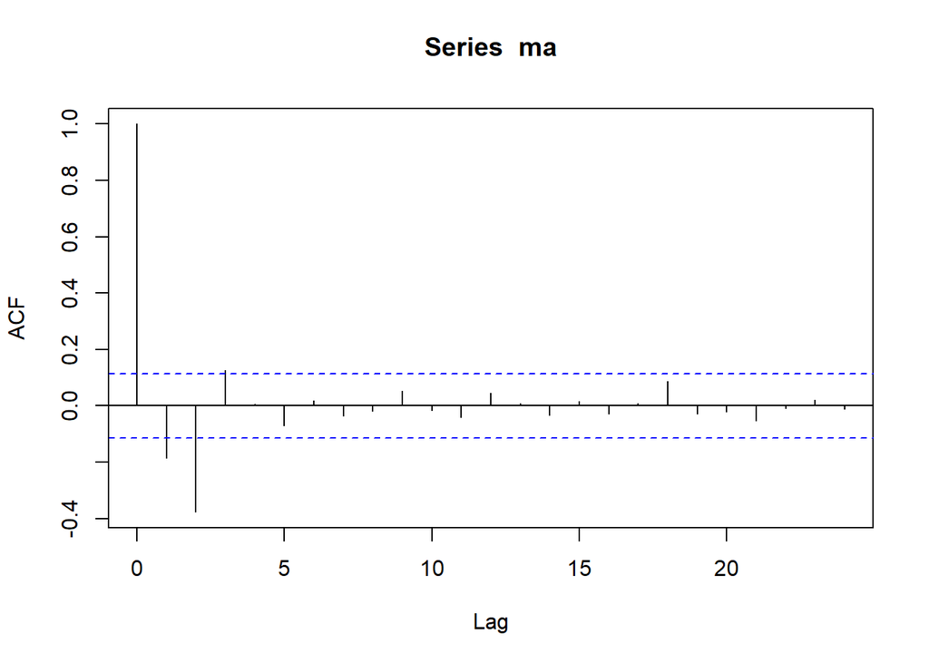

```r
acf(ma)
```

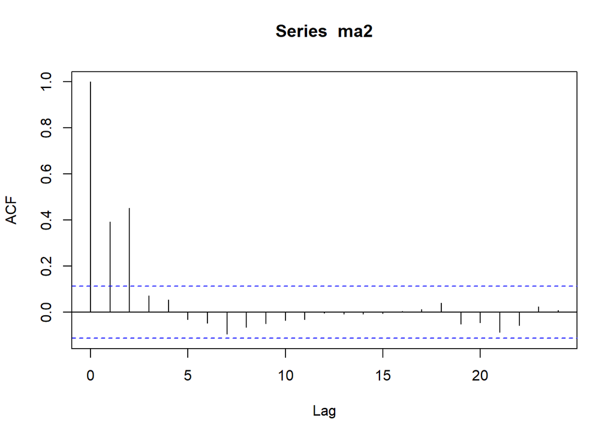

```r
acf(ma2)
```

Berdasarkan plot ACF tersebut, terlihat bahwa plot ACF *cuts off* di lag kedua

### Plot PACF

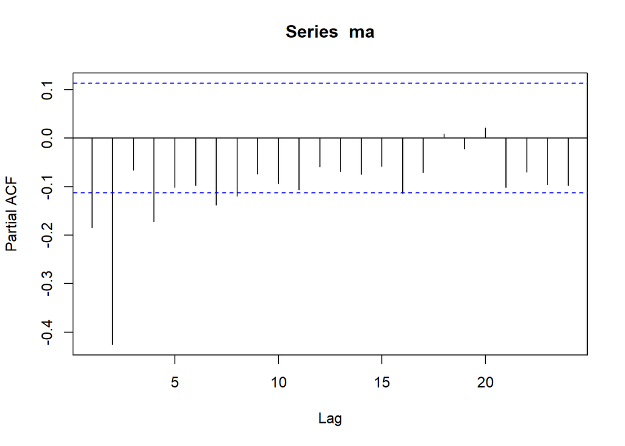

```r
pacf(ma)
```

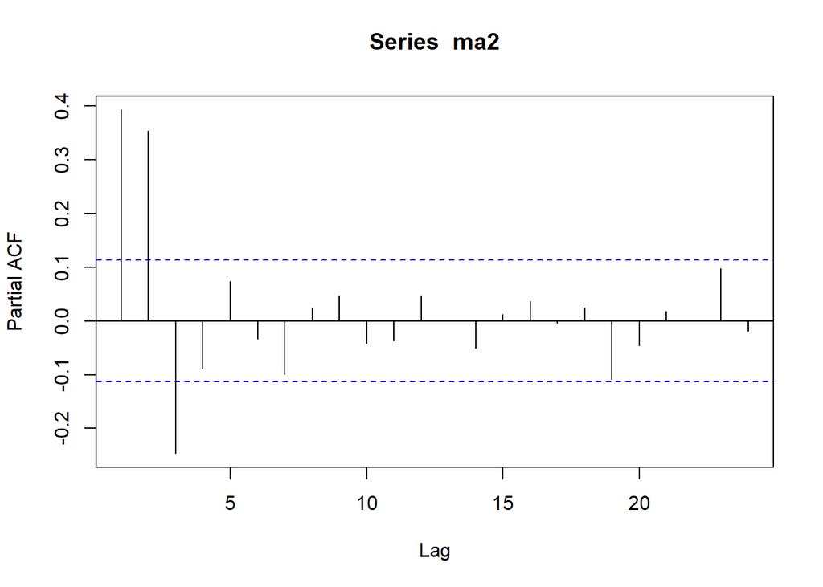

```r
pacf(ma2)
```

Berdasarkan plot PACF, dapat dilihat bahwa plot PACF cenderung *tails off* dan membentuk gelombang lembah karena nilai teta adalah positif.

### Plot EACF

```r
TSA::eacf(ma)
```

```
## AR/MA
##   0 1 2 3 4 5 6 7 8 9 10 11 12 13
## 0 x x x o o o o o o o o  o  o  o
## 1 x x x o o o o o o o o  o  o  o
## 2 x x x x o o o o o o o  o  o  o
## 3 x x o x o o o o o o o  o  o  o
## 4 x x o x o x o o o o o  o  o  o
## 5 x o x o o o o o o o o  o  o  o
## 6 x x x o o o o o o o o  o  o  o
## 7 x x x o o o o o o o o  o  o  o
```

Berdasarkan plot EACF tersebut, terlihat bahwa pola segitiga nol terletak pada ordo AR(0) dan ordo MA(3).

```r
TSA::eacf(ma2)
```

```
## AR/MA
##   0 1 2 3 4 5 6 7 8 9 10 11 12 13
## 0 x x o o o o o o o o o  o  o  o
## 1 x x x o o o o o o o o  o  o  o
## 2 x x x x o o o o o o o  o  o  o
## 3 x x x x x o o o o o o  o  o  o
## 4 x o x x x o o o o o o  o  o  o
## 5 x o x o o o o o o o o  o  o  o
## 6 x x x x o o o o o o o  o  o  o
## 7 x x x x o o o o o o o  o  o  o
```

Berdasarkan plot EACF tersebut, terlihat bahwa pola segitiga nol terletak pada ordo AR(0) dan ordo MA(2).

## Scatter Plot Antar Lag

### Korelasi antara $Y_t$ dengan $Y_{t-1}$

```r
yt_ma <- ma[-1]
yt_ma
```

```
##   [1] -1.821654901  2.486034743 -0.927862261 -0.521669461  1.948461351
##   [6]  0.255901339 -0.434447536 -1.766439330 -1.727770198  0.968296434
##  [11]  1.004394780 -0.918283755  0.498915581  0.112720202 -0.392883899
##  [16] -0.730960704 -0.892792750  0.311492382  1.420485687  0.155107571
##  [21] -0.914831973  1.351547637 -0.412936886 -1.709351263  1.788184011
##  [26]  0.990984267  0.831052821 -1.408879648  0.453766614  0.378118211
##  [31] -0.160936219 -1.267251184 -0.160346499  0.301296192 -0.078055877
##  [36] -1.045575135  0.762239286  0.369918041  1.036275213 -1.077413938
##  [41] -0.413423804  1.112805361 -0.524466480 -1.737545219  1.550777923
##  [46] -1.172062652 -1.154283009  0.897794243  0.405871050 -1.341777693
##  [51]  1.110127382  0.565385513 -2.975554405  1.366551713  2.312114693
##  [56] -0.422459341  0.272322249 -0.814098787  0.413405708  0.103622961
##  [61] -0.549756228 -0.769117100  0.936216616  2.458033248 -0.568212391
##  [66] -1.708530831 -0.052617451  0.660786793 -0.467054790 -0.805911623
##  [71] -0.009858114  0.098025783 -0.782110661  0.493504372 -1.015053687
```

[output cut: 45 more lines]

```r
yt_1_ma <- ma[-300]
yt_1_ma
```

```
##   [1]  1.067940246 -1.821654901  2.486034743 -0.927862261 -0.521669461
##   [6]  1.948461351  0.255901339 -0.434447536 -1.766439330 -1.727770198
##  [11]  0.968296434  1.004394780 -0.918283755  0.498915581  0.112720202
##  [16] -0.392883899 -0.730960704 -0.892792750  0.311492382  1.420485687
##  [21]  0.155107571 -0.914831973  1.351547637 -0.412936886 -1.709351263
##  [26]  1.788184011  0.990984267  0.831052821 -1.408879648  0.453766614
##  [31]  0.378118211 -0.160936219 -1.267251184 -0.160346499  0.301296192
##  [36] -0.078055877 -1.045575135  0.762239286  0.369918041  1.036275213
##  [41] -1.077413938 -0.413423804  1.112805361 -0.524466480 -1.737545219
##  [46]  1.550777923 -1.172062652 -1.154283009  0.897794243  0.405871050
##  [51] -1.341777693  1.110127382  0.565385513 -2.975554405  1.366551713
##  [56]  2.312114693 -0.422459341  0.272322249 -0.814098787  0.413405708
##  [61]  0.103622961 -0.549756228 -0.769117100  0.936216616  2.458033248
##  [66] -0.568212391 -1.708530831 -0.052617451  0.660786793 -0.467054790
##  [71] -0.805911623 -0.009858114  0.098025783 -0.782110661  0.493504372
```

[output cut: 45 more lines]

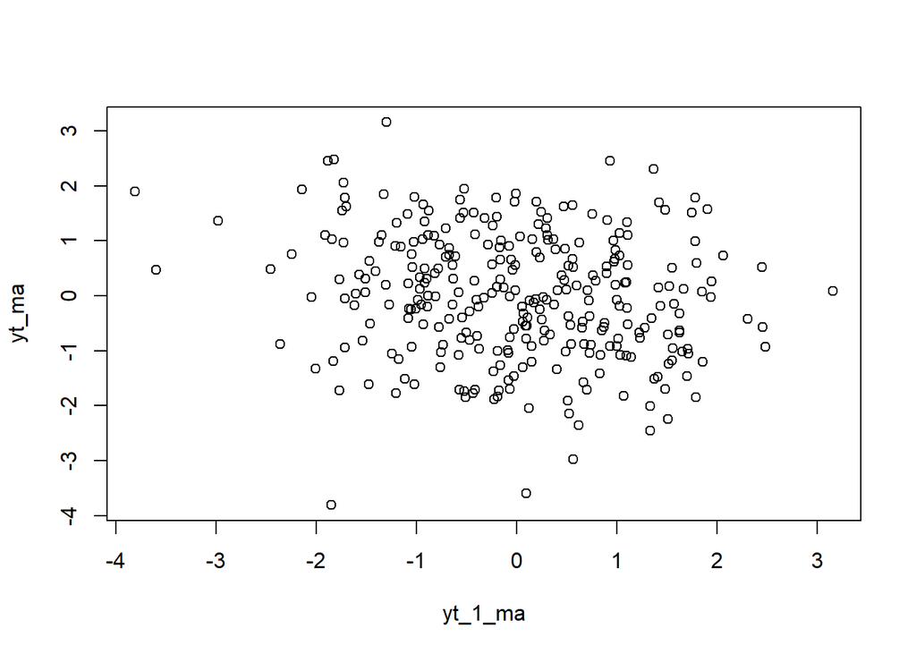

```r
plot(y=yt_ma,x=yt_1_ma)
```

```r
cor(yt_ma,yt_1_ma)
```

```
## [1] -0.1852785
```

### Korelasi antara $Y_t$ dengan $Y_{t-2}$

```r
yt_ma2 <- ma[-c(1,2)]
yt_ma2
```

```
##   [1]  2.486034743 -0.927862261 -0.521669461  1.948461351  0.255901339
##   [6] -0.434447536 -1.766439330 -1.727770198  0.968296434  1.004394780
##  [11] -0.918283755  0.498915581  0.112720202 -0.392883899 -0.730960704
##  [16] -0.892792750  0.311492382  1.420485687  0.155107571 -0.914831973
##  [21]  1.351547637 -0.412936886 -1.709351263  1.788184011  0.990984267
##  [26]  0.831052821 -1.408879648  0.453766614  0.378118211 -0.160936219
##  [31] -1.267251184 -0.160346499  0.301296192 -0.078055877 -1.045575135
##  [36]  0.762239286  0.369918041  1.036275213 -1.077413938 -0.413423804
##  [41]  1.112805361 -0.524466480 -1.737545219  1.550777923 -1.172062652
##  [46] -1.154283009  0.897794243  0.405871050 -1.341777693  1.110127382
##  [51]  0.565385513 -2.975554405  1.366551713  2.312114693 -0.422459341
##  [56]  0.272322249 -0.814098787  0.413405708  0.103622961 -0.549756228
##  [61] -0.769117100  0.936216616  2.458033248 -0.568212391 -1.708530831
##  [66] -0.052617451  0.660786793 -0.467054790 -0.805911623 -0.009858114
##  [71]  0.098025783 -0.782110661  0.493504372 -1.015053687  1.795760339
```

[output cut: 45 more lines]

```r
yt_2_ma <- ma[-c(299,300)]
yt_2_ma
```

```
##   [1]  1.067940246 -1.821654901  2.486034743 -0.927862261 -0.521669461
##   [6]  1.948461351  0.255901339 -0.434447536 -1.766439330 -1.727770198
##  [11]  0.968296434  1.004394780 -0.918283755  0.498915581  0.112720202
##  [16] -0.392883899 -0.730960704 -0.892792750  0.311492382  1.420485687
##  [21]  0.155107571 -0.914831973  1.351547637 -0.412936886 -1.709351263
##  [26]  1.788184011  0.990984267  0.831052821 -1.408879648  0.453766614
##  [31]  0.378118211 -0.160936219 -1.267251184 -0.160346499  0.301296192
##  [36] -0.078055877 -1.045575135  0.762239286  0.369918041  1.036275213
##  [41] -1.077413938 -0.413423804  1.112805361 -0.524466480 -1.737545219
##  [46]  1.550777923 -1.172062652 -1.154283009  0.897794243  0.405871050
##  [51] -1.341777693  1.110127382  0.565385513 -2.975554405  1.366551713
##  [56]  2.312114693 -0.422459341  0.272322249 -0.814098787  0.413405708
##  [61]  0.103622961 -0.549756228 -0.769117100  0.936216616  2.458033248
##  [66] -0.568212391 -1.708530831 -0.052617451  0.660786793 -0.467054790
##  [71] -0.805911623 -0.009858114  0.098025783 -0.782110661  0.493504372
```

[output cut: 45 more lines]

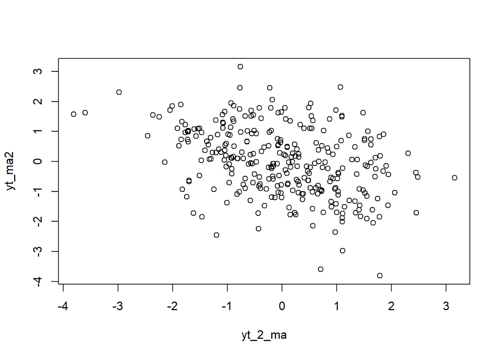

```r
plot(y=yt_ma2,x=yt_2_ma)
```

```r
cor(yt_ma2,yt_2_ma)
```

```
## [1] -0.3798422
```

### Korelasi antara $Y_t$ dengan $Y_{t-3}$

```r
yt_ma3 <- ma[-c(1,2,3)]
yt_ma3
```

```
##   [1] -0.927862261 -0.521669461  1.948461351  0.255901339 -0.434447536
##   [6] -1.766439330 -1.727770198  0.968296434  1.004394780 -0.918283755
##  [11]  0.498915581  0.112720202 -0.392883899 -0.730960704 -0.892792750
##  [16]  0.311492382  1.420485687  0.155107571 -0.914831973  1.351547637
##  [21] -0.412936886 -1.709351263  1.788184011  0.990984267  0.831052821
##  [26] -1.408879648  0.453766614  0.378118211 -0.160936219 -1.267251184
##  [31] -0.160346499  0.301296192 -0.078055877 -1.045575135  0.762239286
##  [36]  0.369918041  1.036275213 -1.077413938 -0.413423804  1.112805361
##  [41] -0.524466480 -1.737545219  1.550777923 -1.172062652 -1.154283009
##  [46]  0.897794243  0.405871050 -1.341777693  1.110127382  0.565385513
##  [51] -2.975554405  1.366551713  2.312114693 -0.422459341  0.272322249
##  [56] -0.814098787  0.413405708  0.103622961 -0.549756228 -0.769117100
##  [61]  0.936216616  2.458033248 -0.568212391 -1.708530831 -0.052617451
##  [66]  0.660786793 -0.467054790 -0.805911623 -0.009858114  0.098025783
##  [71] -0.782110661  0.493504372 -1.015053687  1.795760339  0.598314692
```

[output cut: 45 more lines]

```r
yt_3_ma <- ma[-c(298,299,300)]
yt_3_ma
```

```
##   [1]  1.067940246 -1.821654901  2.486034743 -0.927862261 -0.521669461
##   [6]  1.948461351  0.255901339 -0.434447536 -1.766439330 -1.727770198
##  [11]  0.968296434  1.004394780 -0.918283755  0.498915581  0.112720202
##  [16] -0.392883899 -0.730960704 -0.892792750  0.311492382  1.420485687
##  [21]  0.155107571 -0.914831973  1.351547637 -0.412936886 -1.709351263
##  [26]  1.788184011  0.990984267  0.831052821 -1.408879648  0.453766614
##  [31]  0.378118211 -0.160936219 -1.267251184 -0.160346499  0.301296192
##  [36] -0.078055877 -1.045575135  0.762239286  0.369918041  1.036275213
##  [41] -1.077413938 -0.413423804  1.112805361 -0.524466480 -1.737545219
##  [46]  1.550777923 -1.172062652 -1.154283009  0.897794243  0.405871050
##  [51] -1.341777693  1.110127382  0.565385513 -2.975554405  1.366551713
##  [56]  2.312114693 -0.422459341  0.272322249 -0.814098787  0.413405708
##  [61]  0.103622961 -0.549756228 -0.769117100  0.936216616  2.458033248
##  [66] -0.568212391 -1.708530831 -0.052617451  0.660786793 -0.467054790
##  [71] -0.805911623 -0.009858114  0.098025783 -0.782110661  0.493504372
```

[output cut: 45 more lines]

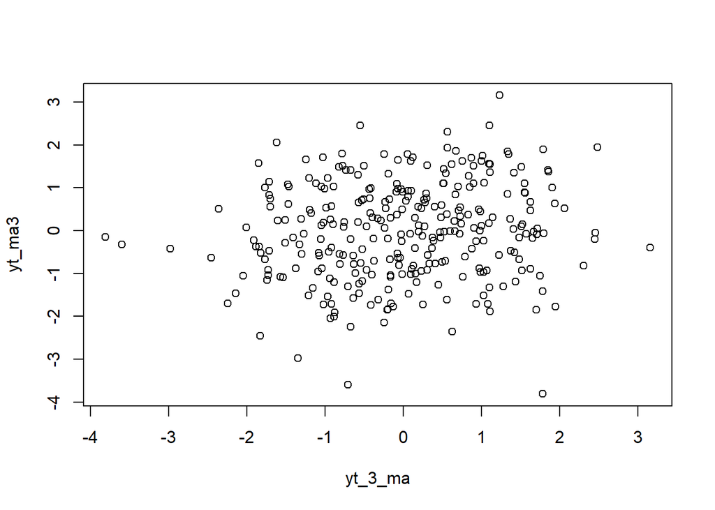

```r
plot(y=yt_ma3,x=yt_3_ma)
```

```r
cor(yt_ma3,yt_3_ma)
```

```
## [1] 0.1277095
```

Berdasarkan scatterplot tersebut, terlihat bahwa hubungan antara $Y_t$ dengan $Y_{t-3}$ hanya memiliki korelasi yang kecil, sebesar 0.1277.

### Perbandingan Korelasi

```r
cor(yt_ma,yt_1_ma)
```

```
## [1] -0.1852785
```

```r
cor(yt_ma2,yt_2_ma)
```

```
## [1] -0.3798422
```

```r
cor(yt_ma3,yt_3_ma)
```

```
## [1] 0.1277095
```

```r
corryt1 <- (-0.4+(0.4*0.6))/(1+(0.4)^2+(0.6)^2)
corryt2 <- -0.6/(1+(0.4)^2+(0.6)^2)
corryt3 <- 0
corryt1
```

```
## [1] -0.1052632
```

```r
corryt2
```

```
## [1] -0.3947368
```

```r
corryt3
```

```
## [1] 0
```

Berdasarkan perbandingan korelasi tersebut, terlihat bahwa nilai korelasi yang didapatkan dari hasil simulasi mendekati nilai korelasi teoritis.

# Proses AR(2)

Akan dibangkitkan suatu data dengan model AR(2) sebanyak 300 data yang memiliki nilai $\phi_1 = 0.5$ dan $\phi_2 = 0.2$. Rumusan model tersebut adalah sebagai berikut:

$$Y_t = e_t+0.5Y_{t-1}+0.2Y_{t-2}$$

```r
set.seed(1009)
ar <- c(1:300)
ar[1] <- wn[1]
ar[2] <- wn[2] + 0.5 * ar [1]
```

```r
for(i in 3:300){
   ar[i] <- wn[i] + 0.5 * ar[i - 1] + 0.2 * ar[i - 2]
}
ar
```

```
##   [1]  1.067940246 -0.860508680  2.352341079  0.267122208  1.328985643
##   [6]  2.514193186  2.932279224  3.176050468  1.736501938  0.324742539
##  [11]  0.743693197  0.827567389 -0.059039584  0.620747869  0.232250742
##  [16]  0.111717446 -0.719863998 -1.636384906 -1.663495151 -0.798348667
##  [21] -0.853293376 -1.333310865  0.142583745 -0.664544712 -1.612837923
##  [26]  0.043718534  0.298045135  1.818148340  0.583208446  1.951039843
##  [31]  1.757317352  2.151476293  0.912087737  1.049512866  0.764671340
##  [36]  0.635085553 -0.523460750  0.255659290 -0.047158120  1.269933297
##  [41]  0.002895918  0.338383472  0.942172358  0.373026281 -0.965451381
##  [46]  0.507055936 -1.549793808 -1.922755504 -1.839389085 -1.875157494
##  [51] -3.216430541 -1.980056088 -2.213236752 -4.708238630 -3.060412127
##  [56] -2.188562703 -2.173693961 -1.269194694 -2.061687106 -1.114998274
##  [61] -1.393750491 -1.537386171 -2.317913151 -1.408911943  0.550721413
##  [66]  0.147383053 -0.431917119 -0.393117731 -0.074261566 -0.623318298
##  [71] -1.210240238 -1.397671785 -1.640250626 -2.562249808 -2.120326725
```

[output cut: 45 more lines]

```r
set.seed(1009)
ar2 <- arima.sim(list(order=c(2,0,0), ar=c(0.5,0.2)), n=300)
ar2
```

```
## Time Series:
## Start = 1
## End = 300
## Frequency = 1
##   [1]  0.043718534  0.298045135  1.818148340  0.583208446  1.951039843
##   [6]  1.757317352  2.151476293  0.912087737  1.049512866  0.764671340
##  [11]  0.635085553 -0.523460750  0.255659290 -0.047158120  1.269933297
##  [16]  0.002895918  0.338383472  0.942172358  0.373026281 -0.965451381
##  [21]  0.507055936 -1.549793808 -1.922755504 -1.839389085 -1.875157494
##  [26] -3.216430541 -1.980056088 -2.213236752 -4.708238630 -3.060412127
##  [31] -2.188562703 -2.173693961 -1.269194694 -2.061687106 -1.114998274
##  [36] -1.393750491 -1.537386171 -2.317913151 -1.408911943  0.550721413
##  [41]  0.147383053 -0.431917119 -0.393117731 -0.074261566 -0.623318298
##  [46] -1.210240238 -1.397671785 -1.640250626 -2.562249808 -2.120326725
##  [51] -3.669681772 -1.608664289 -1.938098099 -0.869471583 -0.957766210
```

[output cut: 49 more lines]

## Karakteristik AR(2)

### Plot Time Series

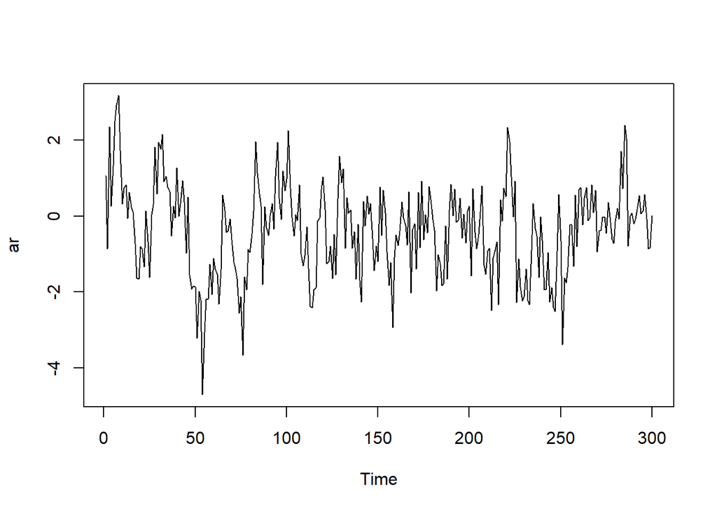

```r
ts.plot(ar)
```

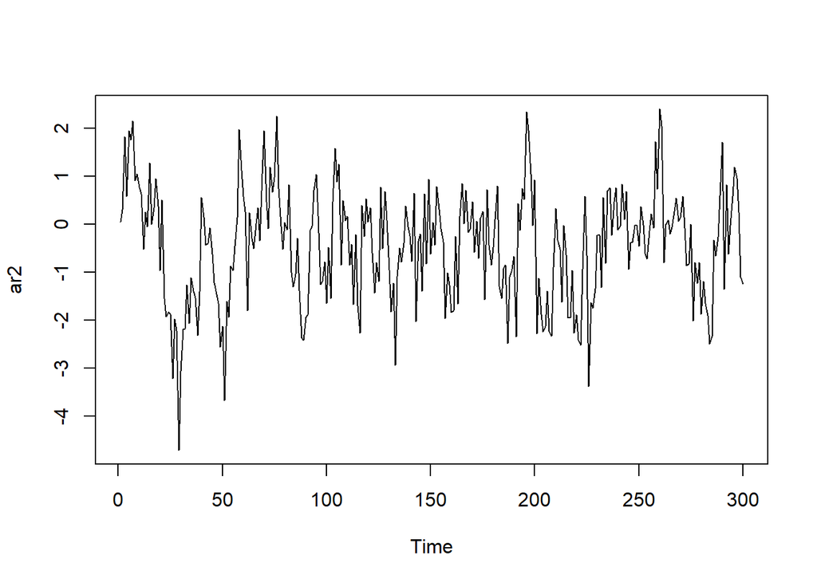

```r
ts.plot(ar2)
```

Berdasarkan plot time series, terlihat bahwa data AR(2) yang dibangkitkan terlihat cenderung stasioner dalam rataan.

### Plot ACF

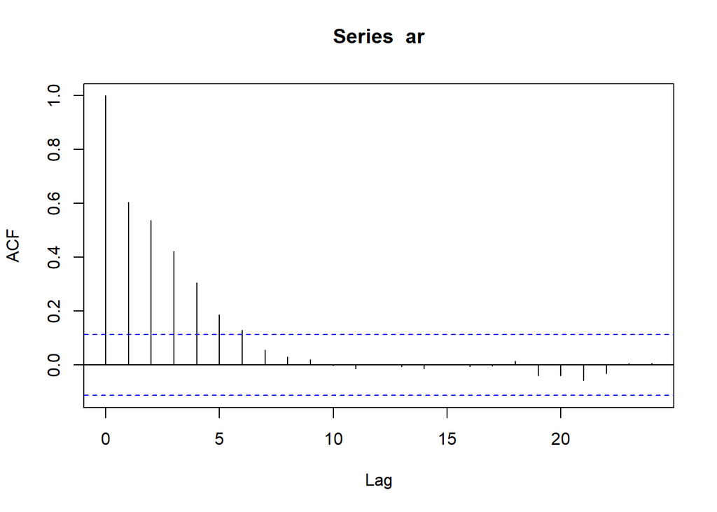

```r
acf(ar)
```

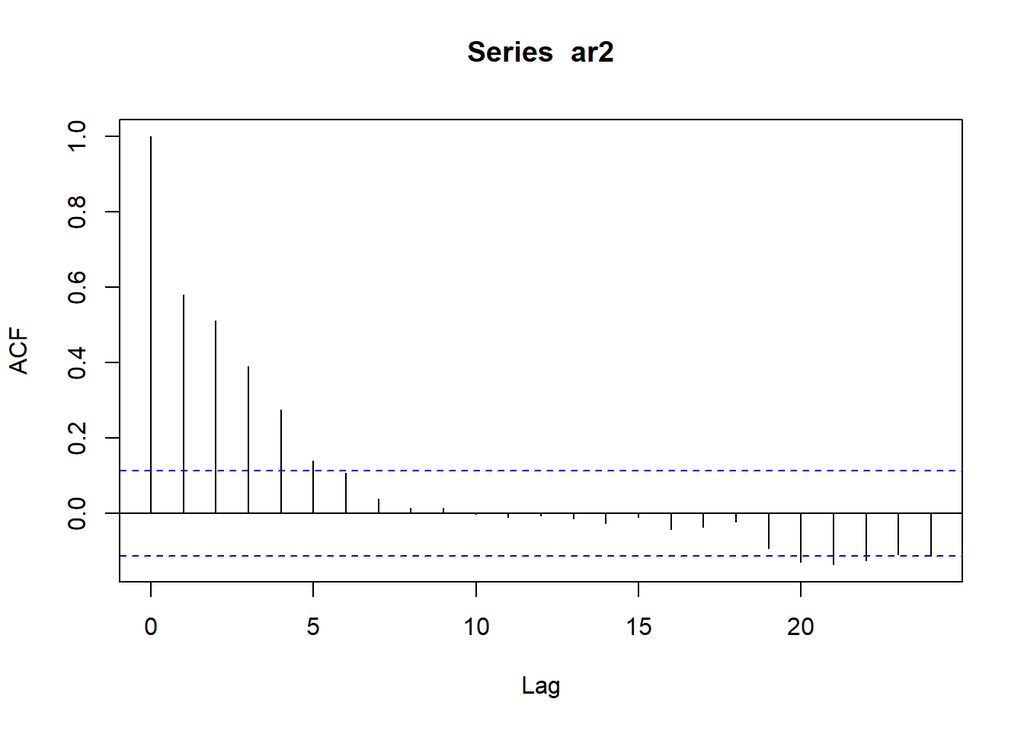

```r
acf(ar2)
```

### Plot PACF

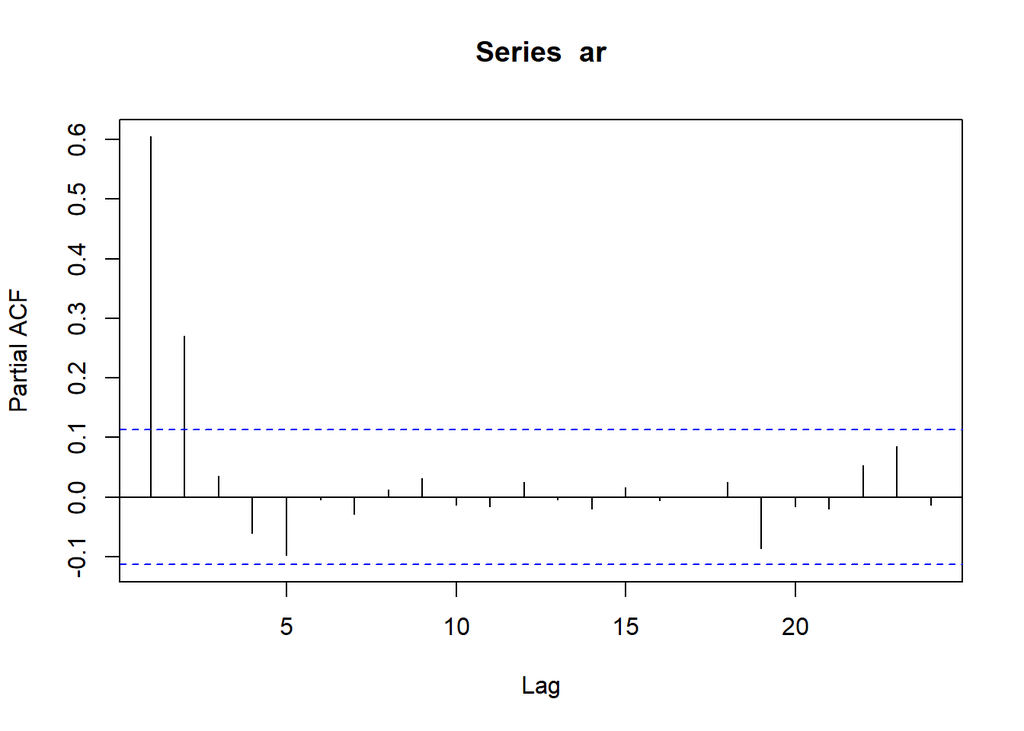

```r
pacf(ar)
```

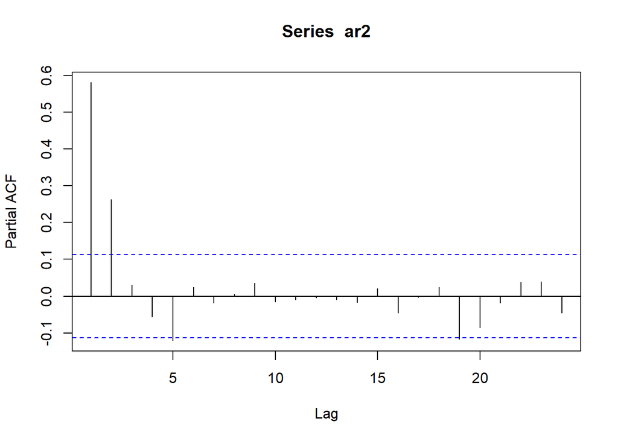

```r
pacf(ar2)
```

Berdasarkan plot PACF tersebut, terlihat bahwa plot PACF *cuts off* di lag kedua

### Plot EACF

```r
TSA::eacf(ar)
```

```
## AR/MA
##   0 1 2 3 4 5 6 7 8 9 10 11 12 13
## 0 x x x x x x o o o o o  o  o  o
## 1 x o o o o o o o o o o  o  o  o
## 2 x x o o o o o o o o o  o  o  o
## 3 x x o o o o o o o o o  o  o  o
## 4 x x x x o o o o o o o  o  o  o
## 5 o x o x o o o o o o o  o  o  o
## 6 o x o x o o o o o o o  o  o  o
## 7 x x o o o o o o o o o  o  o  o
```

```r
TSA::eacf(ar2)
```

```
## AR/MA
##   0 1 2 3 4 5 6 7 8 9 10 11 12 13
## 0 x x x x x o o o o o o  o  o  o
## 1 x o o o o o o o o o o  o  o  o
## 2 x x o o o o o o o o o  o  o  o
## 3 x o x o o o o o o o o  o  o  o
## 4 x x x x o o o o o o o  o  o  o
## 5 x o o x o o o o o o o  o  o  o
## 6 x o o x o o o o o o o  o  o  o
## 7 x o o x x o o o o o o  o  o  o
```

Berdasarkan plot EACF tersebut, terlihat bahwa plot EACF menunjukkan pola segitiga nol pada AR(1) dan MA(1).

## Scatterplot Antar Lag

### Korelasi antara $Y_t$ dengan $Y_{t-1}$

```r
yt_ar <- ar[-1]
yt_ar
```

```
##   [1] -0.860508680  2.352341079  0.267122208  1.328985643  2.514193186
##   [6]  2.932279224  3.176050468  1.736501938  0.324742539  0.743693197
##  [11]  0.827567389 -0.059039584  0.620747869  0.232250742  0.111717446
##  [16] -0.719863998 -1.636384906 -1.663495151 -0.798348667 -0.853293376
##  [21] -1.333310865  0.142583745 -0.664544712 -1.612837923  0.043718534
##  [26]  0.298045135  1.818148340  0.583208446  1.951039843  1.757317352
##  [31]  2.151476293  0.912087737  1.049512866  0.764671340  0.635085553
##  [36] -0.523460750  0.255659290 -0.047158120  1.269933297  0.002895918
##  [41]  0.338383472  0.942172358  0.373026281 -0.965451381  0.507055936
##  [46] -1.549793808 -1.922755504 -1.839389085 -1.875157494 -3.216430541
##  [51] -1.980056088 -2.213236752 -4.708238630 -3.060412127 -2.188562703
##  [56] -2.173693961 -1.269194694 -2.061687106 -1.114998274 -1.393750491
##  [61] -1.537386171 -2.317913151 -1.408911943  0.550721413  0.147383053
##  [66] -0.431917119 -0.393117731 -0.074261566 -0.623318298 -1.210240238
##  [71] -1.397671785 -1.640250626 -2.562249808 -2.120326725 -3.669681772
```

[output cut: 45 more lines]

```r
yt_1_ar <- ar[-300]
yt_1_ar
```

```
##   [1]  1.067940246 -0.860508680  2.352341079  0.267122208  1.328985643
##   [6]  2.514193186  2.932279224  3.176050468  1.736501938  0.324742539
##  [11]  0.743693197  0.827567389 -0.059039584  0.620747869  0.232250742
##  [16]  0.111717446 -0.719863998 -1.636384906 -1.663495151 -0.798348667
##  [21] -0.853293376 -1.333310865  0.142583745 -0.664544712 -1.612837923
##  [26]  0.043718534  0.298045135  1.818148340  0.583208446  1.951039843
##  [31]  1.757317352  2.151476293  0.912087737  1.049512866  0.764671340
##  [36]  0.635085553 -0.523460750  0.255659290 -0.047158120  1.269933297
##  [41]  0.002895918  0.338383472  0.942172358  0.373026281 -0.965451381
##  [46]  0.507055936 -1.549793808 -1.922755504 -1.839389085 -1.875157494
##  [51] -3.216430541 -1.980056088 -2.213236752 -4.708238630 -3.060412127
##  [56] -2.188562703 -2.173693961 -1.269194694 -2.061687106 -1.114998274
##  [61] -1.393750491 -1.537386171 -2.317913151 -1.408911943  0.550721413
##  [66]  0.147383053 -0.431917119 -0.393117731 -0.074261566 -0.623318298
##  [71] -1.210240238 -1.397671785 -1.640250626 -2.562249808 -2.120326725
```

[output cut: 45 more lines]

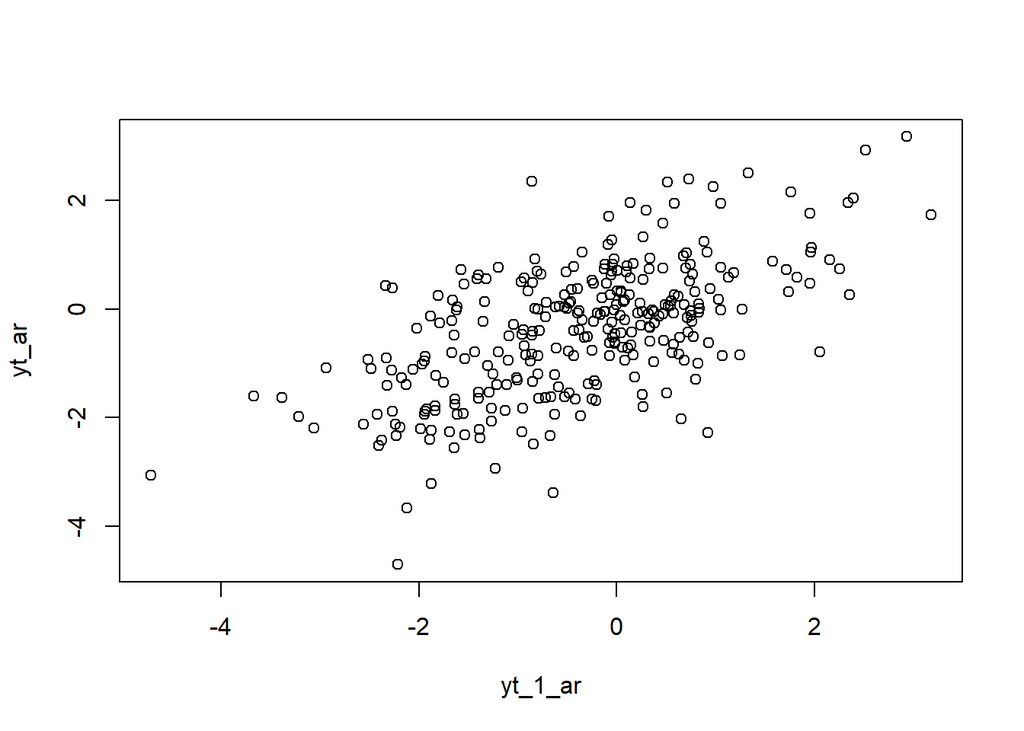

```r
plot(y=yt_ar,x=yt_1_ar)
```

```r
cor(yt_ar,yt_1_ar)
```

```
## [1] 0.6062542
```

Berdasarkan scatterplot tersebut, terlihat bahwa terdapat hubungan positif antara $Y_t$ dengan $Y_{t-1}$. Didapatkan nilai korelasi sebesar 0.6062.

### Korelasi antara $Y_t$ dengan $Y_{t-2}$

```r
yt_ar2 <- ar[-c(1,2)]
yt_ar2
```

```
##   [1]  2.352341079  0.267122208  1.328985643  2.514193186  2.932279224
##   [6]  3.176050468  1.736501938  0.324742539  0.743693197  0.827567389
##  [11] -0.059039584  0.620747869  0.232250742  0.111717446 -0.719863998
##  [16] -1.636384906 -1.663495151 -0.798348667 -0.853293376 -1.333310865
##  [21]  0.142583745 -0.664544712 -1.612837923  0.043718534  0.298045135
##  [26]  1.818148340  0.583208446  1.951039843  1.757317352  2.151476293
##  [31]  0.912087737  1.049512866  0.764671340  0.635085553 -0.523460750
##  [36]  0.255659290 -0.047158120  1.269933297  0.002895918  0.338383472
##  [41]  0.942172358  0.373026281 -0.965451381  0.507055936 -1.549793808
##  [46] -1.922755504 -1.839389085 -1.875157494 -3.216430541 -1.980056088
##  [51] -2.213236752 -4.708238630 -3.060412127 -2.188562703 -2.173693961
##  [56] -1.269194694 -2.061687106 -1.114998274 -1.393750491 -1.537386171
##  [61] -2.317913151 -1.408911943  0.550721413  0.147383053 -0.431917119
##  [66] -0.393117731 -0.074261566 -0.623318298 -1.210240238 -1.397671785
##  [71] -1.640250626 -2.562249808 -2.120326725 -3.669681772 -1.608664289
```

[output cut: 45 more lines]

```r
yt_2_ar <- ar[-c(299,300)]
yt_2_ar
```

```
##   [1]  1.067940246 -0.860508680  2.352341079  0.267122208  1.328985643
##   [6]  2.514193186  2.932279224  3.176050468  1.736501938  0.324742539
##  [11]  0.743693197  0.827567389 -0.059039584  0.620747869  0.232250742
##  [16]  0.111717446 -0.719863998 -1.636384906 -1.663495151 -0.798348667
##  [21] -0.853293376 -1.333310865  0.142583745 -0.664544712 -1.612837923
##  [26]  0.043718534  0.298045135  1.818148340  0.583208446  1.951039843
##  [31]  1.757317352  2.151476293  0.912087737  1.049512866  0.764671340
##  [36]  0.635085553 -0.523460750  0.255659290 -0.047158120  1.269933297
##  [41]  0.002895918  0.338383472  0.942172358  0.373026281 -0.965451381
##  [46]  0.507055936 -1.549793808 -1.922755504 -1.839389085 -1.875157494
##  [51] -3.216430541 -1.980056088 -2.213236752 -4.708238630 -3.060412127
##  [56] -2.188562703 -2.173693961 -1.269194694 -2.061687106 -1.114998274
##  [61] -1.393750491 -1.537386171 -2.317913151 -1.408911943  0.550721413
##  [66]  0.147383053 -0.431917119 -0.393117731 -0.074261566 -0.623318298
##  [71] -1.210240238 -1.397671785 -1.640250626 -2.562249808 -2.120326725
```

[output cut: 45 more lines]

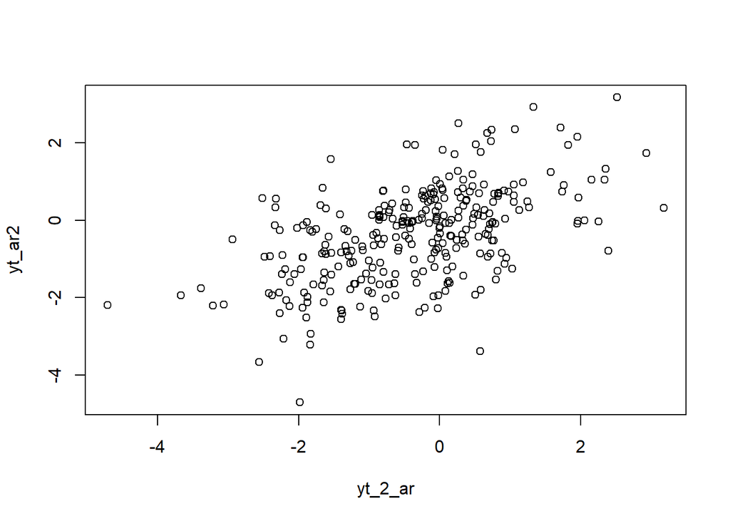

```r
plot(y=yt_ar2,x=yt_2_ar)
```

```r
cor(yt_ar2,yt_2_ar)
```

```
## [1] 0.5389122
```

Berdasarkan scatterplot tersebut, terlihat bahwa terdapat hubungan positif antara $Y_t$ dengan $Y_{t-2}$. Didapatkan nilai korelasi sebesar 0.5389.

### Korelasi antara $Y_t$ dengan $Y_{t-3}$

```r
yt_ar3 <- ar[-c(1,2,3)]
yt_ar3
```

```
##   [1]  0.267122208  1.328985643  2.514193186  2.932279224  3.176050468
##   [6]  1.736501938  0.324742539  0.743693197  0.827567389 -0.059039584
##  [11]  0.620747869  0.232250742  0.111717446 -0.719863998 -1.636384906
##  [16] -1.663495151 -0.798348667 -0.853293376 -1.333310865  0.142583745
##  [21] -0.664544712 -1.612837923  0.043718534  0.298045135  1.818148340
##  [26]  0.583208446  1.951039843  1.757317352  2.151476293  0.912087737
##  [31]  1.049512866  0.764671340  0.635085553 -0.523460750  0.255659290
##  [36] -0.047158120  1.269933297  0.002895918  0.338383472  0.942172358
##  [41]  0.373026281 -0.965451381  0.507055936 -1.549793808 -1.922755504
##  [46] -1.839389085 -1.875157494 -3.216430541 -1.980056088 -2.213236752
##  [51] -4.708238630 -3.060412127 -2.188562703 -2.173693961 -1.269194694
##  [56] -2.061687106 -1.114998274 -1.393750491 -1.537386171 -2.317913151
##  [61] -1.408911943  0.550721413  0.147383053 -0.431917119 -0.393117731
##  [66] -0.074261566 -0.623318298 -1.210240238 -1.397671785 -1.640250626
##  [71] -2.562249808 -2.120326725 -3.669681772 -1.608664289 -1.938098099
```

[output cut: 45 more lines]

```r
yt_3_ar <- ar[-c(298,299,300)]
yt_3_ar
```

```
##   [1]  1.067940246 -0.860508680  2.352341079  0.267122208  1.328985643
##   [6]  2.514193186  2.932279224  3.176050468  1.736501938  0.324742539
##  [11]  0.743693197  0.827567389 -0.059039584  0.620747869  0.232250742
##  [16]  0.111717446 -0.719863998 -1.636384906 -1.663495151 -0.798348667
##  [21] -0.853293376 -1.333310865  0.142583745 -0.664544712 -1.612837923
##  [26]  0.043718534  0.298045135  1.818148340  0.583208446  1.951039843
##  [31]  1.757317352  2.151476293  0.912087737  1.049512866  0.764671340
##  [36]  0.635085553 -0.523460750  0.255659290 -0.047158120  1.269933297
##  [41]  0.002895918  0.338383472  0.942172358  0.373026281 -0.965451381
##  [46]  0.507055936 -1.549793808 -1.922755504 -1.839389085 -1.875157494
##  [51] -3.216430541 -1.980056088 -2.213236752 -4.708238630 -3.060412127
##  [56] -2.188562703 -2.173693961 -1.269194694 -2.061687106 -1.114998274
##  [61] -1.393750491 -1.537386171 -2.317913151 -1.408911943  0.550721413
##  [66]  0.147383053 -0.431917119 -0.393117731 -0.074261566 -0.623318298
##  [71] -1.210240238 -1.397671785 -1.640250626 -2.562249808 -2.120326725
```

[output cut: 45 more lines]

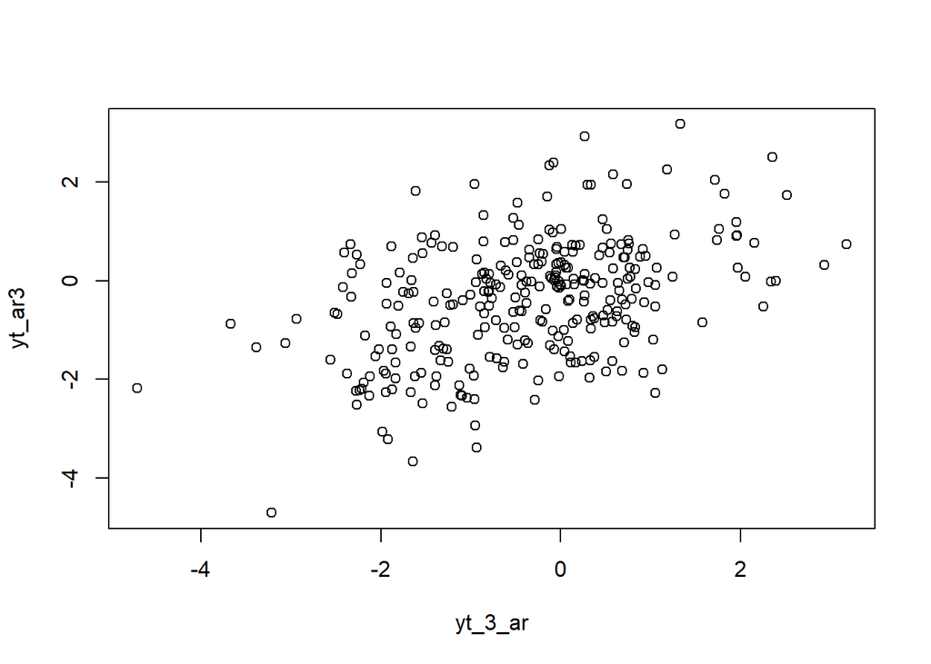

```r
plot(y=yt_ar3,x=yt_3_ar)
```

```r
cor(yt_ar3,yt_3_ar)
```

```
## [1] 0.4264824
```

Berdasarkan scatterplot tersebut, terlihat bahwa terdapat hubungan positif antara $Y_t$ dengan $Y_{t-3}$. Didapatkan nilai korelasi sebesar 0.4265.

### Perbandingan Korelasi

```r
cor(yt_ar,yt_1_ar)
```

```
## [1] 0.6062542
```

```r
cor(yt_ar2,yt_2_ar)
```

```
## [1] 0.5389122
```

```r
cor(yt_ar3,yt_3_ar)
```

```
## [1] 0.4264824
```

```r
corraryt1 <- 0.5/(1-0.2)
corraryt2 <- (0.5*corraryt1)+0.2
corraryt3 <- (0.5*corraryt2)+(0.2*corraryt1)
corraryt1
```

```
## [1] 0.625
```

```r
corraryt2
```

```
## [1] 0.5125
```

```r
corraryt3
```

```
## [1] 0.38125
```

Berdasarkan perbandingan korelasi tersebut, terlihat bahwa nilai korelasi yang didapatkan dari hasil simulasi mendekati nilai korelasi teoritis.

# Proses ARMA(2,2)

Dalam kasus ini, akan dibangkitkan suatu data dengan model ARMA(2,2) sebanyak 300 data yang memiliki nilai $\phi_1 = 0.5$ dan $\phi_2 = 0.2$ serta $\theta_1 = 0.4$ dan $\theta_2 = 0.6$. Rumusan model tersebut adalah sebagai berikut:

$$Y_t =
0.5Y_{t-1}+0.2Y_{t-2}+e_t-0.4_{t-1}-0.6_{t-2}$$

```r
set.seed(1009)
y.arma=c(1:300)
for (i in 3:300){y.arma[i] = 0.5*y.arma[i-1] + 0.2*y.arma[i-2] +
                 wn[i] - 0.4*wn[i-1] - 0.6*wn[i-2]}
y.arma
```

```
##   [1]  1.000000000  2.000000000  3.686034743  1.315155110  0.873115043
##   [6]  2.648049894  1.754549295  0.972437090 -0.929310926 -1.997938243
##  [11] -0.216534872  0.496539696 -0.713320882  0.241563079  0.090837565
##  [16] -0.299152500 -0.862369441 -1.383807970 -0.552885492  0.867281347
##  [21]  0.478171146 -0.502290130  1.196036801  0.084623489 -1.427832158
##  [26]  1.091192630  1.251014150  1.674798422 -0.321277607  0.628087494
##  [31]  0.627906436  0.278634498 -1.002352648 -0.605795923 -0.202072299
##  [36] -0.300251211 -1.236115200  0.084131444  0.164760722  1.135481863
##  [41] -0.476720862 -0.424687862  0.805117258 -0.206845423 -1.679944479
##  [46]  0.669436599 -1.173333249 -1.607062314 -0.140403564  0.014256805
##  [51] -1.362730003  0.431613742  0.508646384 -2.634908465  0.150826757
##  [56]  1.860546379  0.537979199  0.913421124 -0.249792385  0.471193740
##  [61]  0.289261354 -0.310886803 -0.866708231  0.440685140  2.505034173
##  [66]  0.772441723 -0.821303135 -0.308780674  0.342135829 -0.357743010
##  [71] -0.916355962 -0.539584697 -0.355037758 -1.067546479 -0.111276420
```

[output cut: 45 more lines]

```r
set.seed(1009)
arma22 <- arima.sim(list(order=c(2,0,2), ar = c(0.5,0.2), ma = c(0.4,0.6)), n=300)
arma22
```

```
## Time Series:
## Start = 1
## End = 300
## Frequency = 1
##   [1]  1.96369584  1.48936982  3.27526937  2.88770192  4.02506035  2.82709398
##   [7]  2.70525304  1.73174384  1.57067303  0.18938483  0.42733284 -0.25896588
##  [13]  1.40446941  0.48257725  1.10150402  1.07926498  0.95292659 -0.25093648
##  [19]  0.34469190 -1.92624170 -2.23843903 -3.53836724 -3.76456618 -5.07012680
##  [25] -4.39172265 -4.93511740 -6.78156690 -6.27164957 -6.23767068 -4.88536628
##  [31] -3.45180987 -3.87358134 -2.70118992 -3.07676205 -2.76388532 -3.76911791
##  [37] -3.25850890 -1.40359125 -0.47767554 -0.04253105 -0.47745474 -0.49065893
##  [43] -0.88889356 -1.50412450 -2.25575886 -2.92546348 -4.05695313 -4.12937702
##  [49] -6.05516235 -4.34873303 -4.78337288 -2.60990940 -2.46841370 -1.36670358
##  [55] -0.62316903  1.74505720  1.99544758  2.21338078  1.17361323 -1.34595821
##  [61] -0.31736316 -1.28146160 -0.47966556 -0.37389121  0.03285415 -0.20799534
```

[output cut: 39 more lines]

## Karakteristik ARMA(2,2)

### Plot Time Series

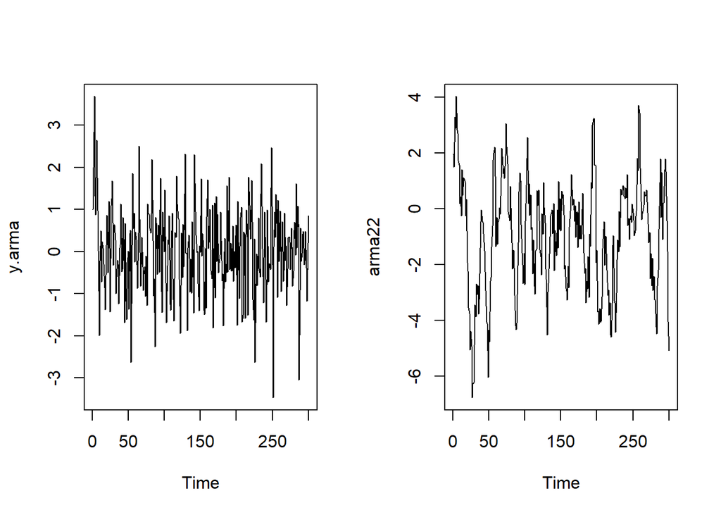

```r
par(mfrow = c(1, 2))
ts.plot(y.arma)
ts.plot(arma22)
```

Berdasarkan plot time series, terlihat bahwa data ARMA(2,2) yang dibangkitkan terlihat cenderung stasioner dalam rataan.

### Plot ACF

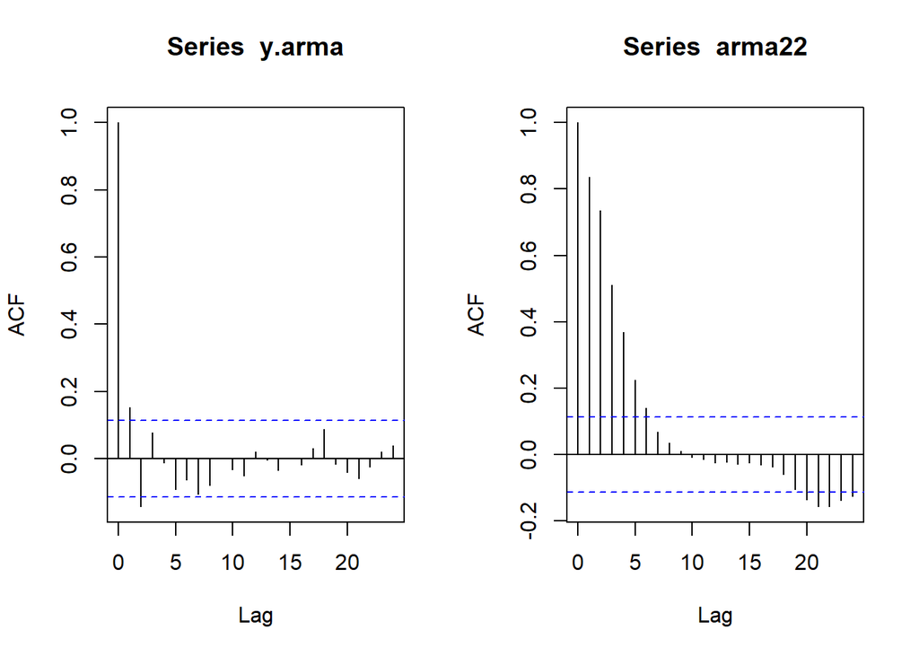

```r
par(mfrow = c(1, 2))
acf(y.arma)
acf(arma22)
```

Berdasarkan plot ACF tersebut, terlihat bahwa plot ACF cenderung *tails off* dan membentuk gelombang sinus

### Plot PACF

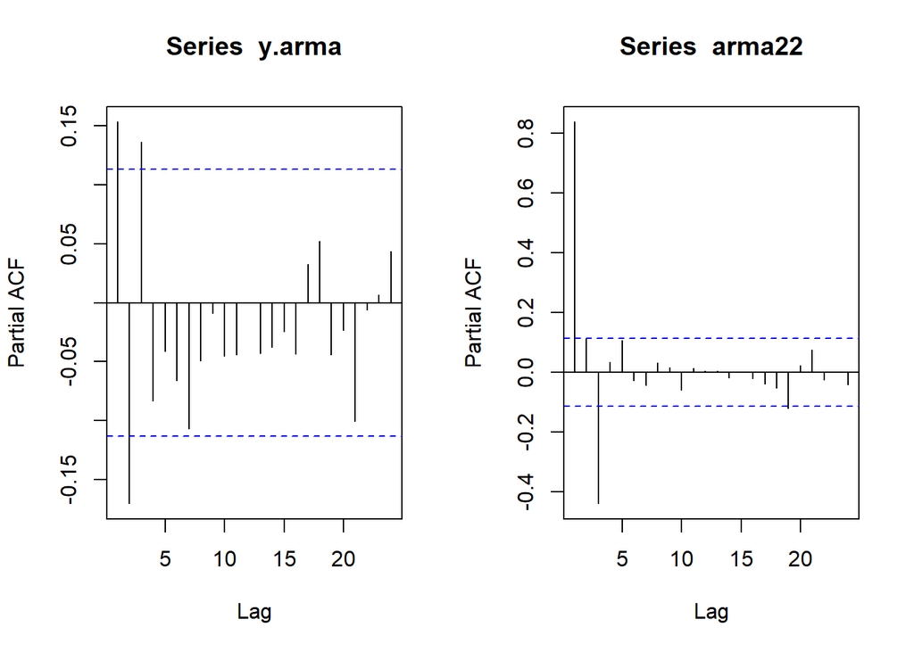

```r
par(mfrow = c(1, 2))
pacf(y.arma)
pacf(arma22)
```

Berdasarkan plot PACF tersebut, terlihat bahwa plot PACF cenderung *tails off*.

### Plot EACF

```r
TSA::eacf(y.arma)
```

```
## AR/MA
##   0 1 2 3 4 5 6 7 8 9 10 11 12 13
## 0 x x o o o o o o o o o  o  o  o
## 1 x o o o o o o o o o o  o  o  o
## 2 x x o x o o o o o o o  o  o  o
## 3 x o o o o o o o o o o  o  o  o
## 4 x x o x o o o o o o o  o  o  o
## 5 x o o x o o o o o o o  o  o  o
## 6 x o x o o o o o o o o  o  o  o
## 7 x o x o o o o o o o o  o  o  o
```

Berdasarkan plot EACF tersebut, terlihat bahwa pola segitiga nol terletak pada ordo AR(0) dan ordo MA(2).

```r
TSA::eacf(arma22)
```

```
## AR/MA
##   0 1 2 3 4 5 6 7 8 9 10 11 12 13
## 0 x x x x x x o o o o o  o  o  o
## 1 x x o x o o o o o o o  o  o  o
## 2 x x o x o o o o o o o  o  o  o
## 3 o x o o o o o o o o o  o  o  o
## 4 x x x o x o o o o o o  o  o  o
## 5 x x o o o o o o o o o  o  o  o
## 6 x x x o o o x o o o o  o  o  o
## 7 x x o x o o x o o o o  o  o  o
```

Berdasarkan plot EACF tersebut, terlihat bahwa pola segitiga nol terletak pada ordo AR(1) dan ordo MA(4).

## Scatterplot Antar Lag

### Korelasi antara $Y_t$ dengan $Y_{t-1}$

```r
yt_arma <- y.arma[-1]
yt_arma
```

```
##   [1]  2.000000000  3.686034743  1.315155110  0.873115043  2.648049894
##   [6]  1.754549295  0.972437090 -0.929310926 -1.997938243 -0.216534872
##  [11]  0.496539696 -0.713320882  0.241563079  0.090837565 -0.299152500
##  [16] -0.862369441 -1.383807970 -0.552885492  0.867281347  0.478171146
##  [21] -0.502290130  1.196036801  0.084623489 -1.427832158  1.091192630
##  [26]  1.251014150  1.674798422 -0.321277607  0.628087494  0.627906436
##  [31]  0.278634498 -1.002352648 -0.605795923 -0.202072299 -0.300251211
##  [36] -1.236115200  0.084131444  0.164760722  1.135481863 -0.476720862
##  [41] -0.424687862  0.805117258 -0.206845423 -1.679944479  0.669436599
##  [46] -1.173333249 -1.607062314 -0.140403564  0.014256805 -1.362730003
##  [51]  0.431613742  0.508646384 -2.634908465  0.150826757  1.860546379
##  [56]  0.537979199  0.913421124 -0.249792385  0.471193740  0.289261354
##  [61] -0.310886803 -0.866708231  0.440685140  2.505034173  0.772441723
##  [66] -0.821303135 -0.308780674  0.342135829 -0.357743010 -0.916355962
##  [71] -0.539584697 -0.355037758 -1.067546479 -0.111276420 -1.284201193
```

[output cut: 45 more lines]

```r
yt_1_arma <- y.arma[-300]
yt_1_arma
```

```
##   [1]  1.000000000  2.000000000  3.686034743  1.315155110  0.873115043
##   [6]  2.648049894  1.754549295  0.972437090 -0.929310926 -1.997938243
##  [11] -0.216534872  0.496539696 -0.713320882  0.241563079  0.090837565
##  [16] -0.299152500 -0.862369441 -1.383807970 -0.552885492  0.867281347
##  [21]  0.478171146 -0.502290130  1.196036801  0.084623489 -1.427832158
##  [26]  1.091192630  1.251014150  1.674798422 -0.321277607  0.628087494
##  [31]  0.627906436  0.278634498 -1.002352648 -0.605795923 -0.202072299
##  [36] -0.300251211 -1.236115200  0.084131444  0.164760722  1.135481863
##  [41] -0.476720862 -0.424687862  0.805117258 -0.206845423 -1.679944479
##  [46]  0.669436599 -1.173333249 -1.607062314 -0.140403564  0.014256805
##  [51] -1.362730003  0.431613742  0.508646384 -2.634908465  0.150826757
##  [56]  1.860546379  0.537979199  0.913421124 -0.249792385  0.471193740
##  [61]  0.289261354 -0.310886803 -0.866708231  0.440685140  2.505034173
##  [66]  0.772441723 -0.821303135 -0.308780674  0.342135829 -0.357743010
##  [71] -0.916355962 -0.539584697 -0.355037758 -1.067546479 -0.111276420
```

[output cut: 45 more lines]

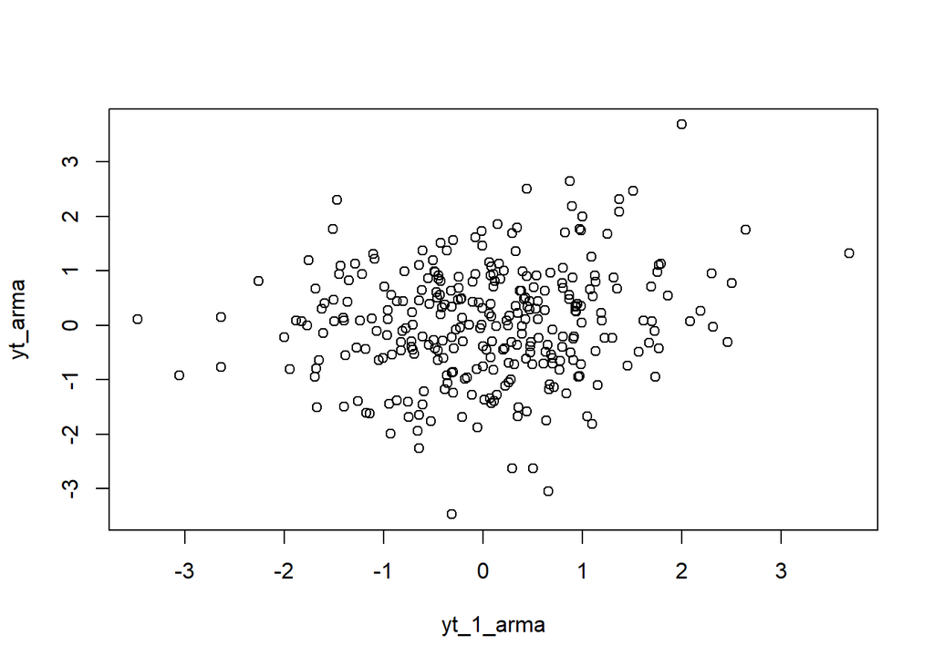

```r
plot(y=yt_arma,x=yt_1_arma)
```

Berdasarkan scatterplot tersebut, terlihat bahwa terdapat hubungan yang lemah antara $Y_t$ dengan $Y_{t-1}$.

```r
cor(yt_arma,yt_1_arma)
```

```
## [1] 0.1538142
```

$$\rho_1 = \frac{(1 - \phi_2)\theta_1 + (\phi_1 - \phi_2)\theta_2 +
\phi_1(1 + \theta_1^2 + \theta_2^2)}
{(1 - \phi_2)(1 + \theta_1^2 + \theta_2^2) + 2(\phi_1 -
\phi_2)\theta_1\theta_2}
= \frac{(1 - 0.2)(0.4) + (0.5 - 0.2)(0.6) + 0.5(1 + 0.4^2 + 0.6^2)}
{(1 - 0.2)(1 + 0.4^2 + 0.6^2) + 2(0.5 - 0.2)(0.4)(0.6)}
= \frac{1.26}{1.36} \approx 0.926$$

Berdasarkan korelasi, korelasi simulasi berbeda jauh dengan korelasi teoritis.

### Korelasi antara $Y_t$ dengan $Y_{t-2}$

```r
yt_arma2 <- y.arma[-c(1,2)]
yt_arma2
```

```
##   [1]  3.686034743  1.315155110  0.873115043  2.648049894  1.754549295
##   [6]  0.972437090 -0.929310926 -1.997938243 -0.216534872  0.496539696
##  [11] -0.713320882  0.241563079  0.090837565 -0.299152500 -0.862369441
##  [16] -1.383807970 -0.552885492  0.867281347  0.478171146 -0.502290130
##  [21]  1.196036801  0.084623489 -1.427832158  1.091192630  1.251014150
##  [26]  1.674798422 -0.321277607  0.628087494  0.627906436  0.278634498
##  [31] -1.002352648 -0.605795923 -0.202072299 -0.300251211 -1.236115200
##  [36]  0.084131444  0.164760722  1.135481863 -0.476720862 -0.424687862
##  [41]  0.805117258 -0.206845423 -1.679944479  0.669436599 -1.173333249
##  [46] -1.607062314 -0.140403564  0.014256805 -1.362730003  0.431613742
##  [51]  0.508646384 -2.634908465  0.150826757  1.860546379  0.537979199
##  [56]  0.913421124 -0.249792385  0.471193740  0.289261354 -0.310886803
##  [61] -0.866708231  0.440685140  2.505034173  0.772441723 -0.821303135
##  [66] -0.308780674  0.342135829 -0.357743010 -0.916355962 -0.539584697
##  [71] -0.355037758 -1.067546479 -0.111276420 -1.284201193  1.131404459
```

[output cut: 45 more lines]

```r
yt_2_arma <- y.arma[-c(299,300)]
yt_2_arma
```

```
##   [1]  1.000000000  2.000000000  3.686034743  1.315155110  0.873115043
##   [6]  2.648049894  1.754549295  0.972437090 -0.929310926 -1.997938243
##  [11] -0.216534872  0.496539696 -0.713320882  0.241563079  0.090837565
##  [16] -0.299152500 -0.862369441 -1.383807970 -0.552885492  0.867281347
##  [21]  0.478171146 -0.502290130  1.196036801  0.084623489 -1.427832158
##  [26]  1.091192630  1.251014150  1.674798422 -0.321277607  0.628087494
##  [31]  0.627906436  0.278634498 -1.002352648 -0.605795923 -0.202072299
##  [36] -0.300251211 -1.236115200  0.084131444  0.164760722  1.135481863
##  [41] -0.476720862 -0.424687862  0.805117258 -0.206845423 -1.679944479
##  [46]  0.669436599 -1.173333249 -1.607062314 -0.140403564  0.014256805
##  [51] -1.362730003  0.431613742  0.508646384 -2.634908465  0.150826757
##  [56]  1.860546379  0.537979199  0.913421124 -0.249792385  0.471193740
##  [61]  0.289261354 -0.310886803 -0.866708231  0.440685140  2.505034173
##  [66]  0.772441723 -0.821303135 -0.308780674  0.342135829 -0.357743010
##  [71] -0.916355962 -0.539584697 -0.355037758 -1.067546479 -0.111276420
```

[output cut: 45 more lines]

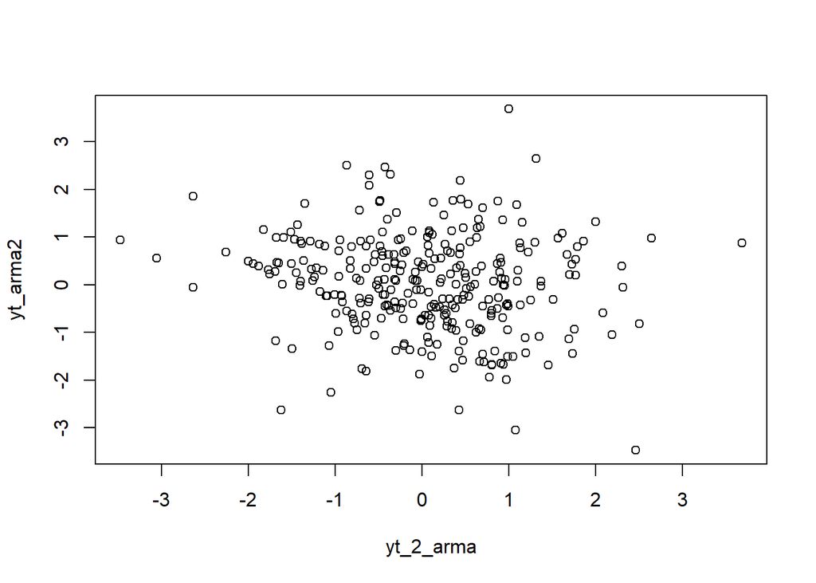

```r
plot(y=yt_arma2,x=yt_2_arma)
```

Berdasarkan scatterplot tersebut, terlihat bahwa terdapat hubungan yang lemah antara $Y_t$ dengan $Y_{t-2}$.

```r
cor(yt_arma2,yt_2_arma)
```

```
## [1] -0.1442152
```

$$\rho_2 = \frac{(\phi_1 + \theta_1\theta_2)(1 - \phi_2) + (\phi_1^2 -
\phi_2)(1 + \theta_1^2 + \theta_2^2) + \theta_2(\theta_1 +
\phi_1\theta_2)}
{(1 - \phi_2)(1 + \theta_1^2 + \theta_2^2) + 2(\phi_1 -
\phi_2)\theta_1\theta_2}
= \frac{(0.5 + 0.4 \times 0.6)(0.8) + (0.5^2 - 0.2)(1 + 0.4^2 + 0.6^2) +
0.6(0.4 + 0.5 \times 0.6)}
{(1-0.2)(1 + 0.4^2 + 0.6^2) + 2(0.5 - 0.2)(0.4)(0.6)}
= \frac{1.088}{1.36} = 0.8$$

Berdasarkan korelasi, korelasi simulasi berbeda jauh dengan korelasi teoritis.

### Korelasi antara $Y_t$ dengan $Y_{t-3}$

```r
yt_arma3 <- y.arma[-c(1,2,3)]
yt_arma3
```

```
##   [1]  1.315155110  0.873115043  2.648049894  1.754549295  0.972437090
##   [6] -0.929310926 -1.997938243 -0.216534872  0.496539696 -0.713320882
##  [11]  0.241563079  0.090837565 -0.299152500 -0.862369441 -1.383807970
##  [16] -0.552885492  0.867281347  0.478171146 -0.502290130  1.196036801
##  [21]  0.084623489 -1.427832158  1.091192630  1.251014150  1.674798422
##  [26] -0.321277607  0.628087494  0.627906436  0.278634498 -1.002352648
##  [31] -0.605795923 -0.202072299 -0.300251211 -1.236115200  0.084131444
##  [36]  0.164760722  1.135481863 -0.476720862 -0.424687862  0.805117258
##  [41] -0.206845423 -1.679944479  0.669436599 -1.173333249 -1.607062314
##  [46] -0.140403564  0.014256805 -1.362730003  0.431613742  0.508646384
##  [51] -2.634908465  0.150826757  1.860546379  0.537979199  0.913421124
##  [56] -0.249792385  0.471193740  0.289261354 -0.310886803 -0.866708231
##  [61]  0.440685140  2.505034173  0.772441723 -0.821303135 -0.308780674
##  [66]  0.342135829 -0.357743010 -0.916355962 -0.539584697 -0.355037758
##  [71] -1.067546479 -0.111276420 -1.284201193  1.131404459  0.907176682
```

[output cut: 45 more lines]

```r
yt_3_arma <- y.arma[-c(298,299,300)]
yt_3_arma
```

```
##   [1]  1.000000000  2.000000000  3.686034743  1.315155110  0.873115043
##   [6]  2.648049894  1.754549295  0.972437090 -0.929310926 -1.997938243
##  [11] -0.216534872  0.496539696 -0.713320882  0.241563079  0.090837565
##  [16] -0.299152500 -0.862369441 -1.383807970 -0.552885492  0.867281347
##  [21]  0.478171146 -0.502290130  1.196036801  0.084623489 -1.427832158
##  [26]  1.091192630  1.251014150  1.674798422 -0.321277607  0.628087494
##  [31]  0.627906436  0.278634498 -1.002352648 -0.605795923 -0.202072299
##  [36] -0.300251211 -1.236115200  0.084131444  0.164760722  1.135481863
##  [41] -0.476720862 -0.424687862  0.805117258 -0.206845423 -1.679944479
##  [46]  0.669436599 -1.173333249 -1.607062314 -0.140403564  0.014256805
##  [51] -1.362730003  0.431613742  0.508646384 -2.634908465  0.150826757
##  [56]  1.860546379  0.537979199  0.913421124 -0.249792385  0.471193740
##  [61]  0.289261354 -0.310886803 -0.866708231  0.440685140  2.505034173
##  [66]  0.772441723 -0.821303135 -0.308780674  0.342135829 -0.357743010
##  [71] -0.916355962 -0.539584697 -0.355037758 -1.067546479 -0.111276420
```

[output cut: 45 more lines]

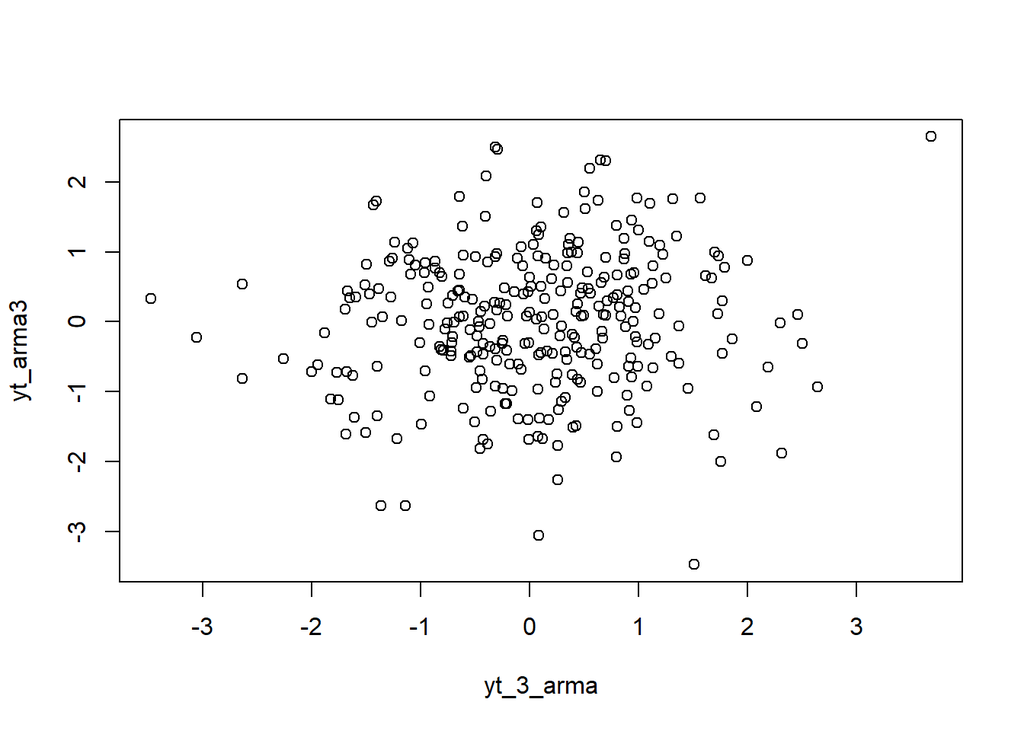

```r
plot(y=yt_arma3,x=yt_3_arma)
```

Berdasarkan scatterplot tersebut, terlihat bahwa terdapat hubungan yang lemah antara $Y_t$ dengan $Y_{t-3}$.

```r
cor(yt_arma3,yt_3_arma)
```

```
## [1] 0.08014733
```

$$\rho_3 = \phi_1 \rho_2 + \phi_2 \rho_1
= (0.5)(0.8) + (0.2)(0.926)
= 0.5852$$

Berdasarkan korelasi, korelasi simulasi berbeda jauh dengan korelasi teoritis.